# Energy Use of Appliances

Yosef Woldeamanuel

Jonathan De Los Santos

12/2020

[output not shown]

[output not shown]

[output not shown]

## Introduction

### Appliances

In most households around the world, there are multiple electrical appliances that consume energy either throughout the day or when used. Modern appliances have the options to be in standby mode to save energy when they are not used. Some appliances such as refrigerators, modems ,and security cameras are required to be powered all the time and consume energy continuously.

In this dataset, we examine a low-energy home outfitted with multiple IoT devices to measure temperature (T) and relative humidity (RH) in multiple rooms along with the energy expended by lights and appliances in watt-hours (Wh). Weather data is also provided from a nearby weather station to improve the prediction modeling.

### Energy Consumption

The amount of energy needed for a specific house will depend on many factors such as the number of appliances, frequency of use, geographical location and climate, number of occupants and efficiency of the house itself. The overall energy usage of a house can easily be aggregated but knowing individual factors which contributes in higher usage is not an easy task.

“Data driven prediction models of energy use of appliances in a low-energy house” is a paper by Luis M.Candanedo, Véronique Feldheim and Dominique Deramaix which presented and discussed data driven prediction models of energy use of appliances. Temperature and humidity data collected at different part of house for this paper will be used to apply multivariate analysis, data cleaning techniques, and other data visualization skills we learned in this course.

We are interested on knowing how the inside and outside temperature, humidity and other parameters affect the energy consumption of appliances in the house and how variables are related to each other.

### Methodology

To determine those relationships, we examine the correlations, perform dimension reduction analysis graphically and using principal component analysis, cluster analysis, and confirmatory factor analysis. The correlation matrices reveal that there is a correlation between inside temperature, humidity, and appliance energy use. Additionally, we find that specific rooms have stronger correlations likely due to the specific appliances they contain.

PCA tells us that temperature is responsible for the highest variance of our dataset, followed by humidity. This may be due to the multiple variables for each that represent the temperature and humidity in different rooms. However, the correlation may imply that small differences in appliance and light energy use affect large variations in temperature and humidity. Finally, the cluster analysis performed on the first two principal components shows obvious clusters of temperatures and humidities. This is presented to show the strength of PCA in identifying variable groups, even if they were understood beforehand. Our model for confirmatory factor analysis was unfortunately not supported by the data, but some approaches for future model attempts are discussed below.

**Attribute Information:**

- date time year-month-day hour:minute:second
- Appliances, energy use in Wh
- lights, energy use of light fixtures in the house in Wh
- T1, Temperature in kitchen area, in Celsius
- RH_1, Humidity in kitchen area, in %
- T2, Temperature in living room area, in Celsius
- RH_2, Humidity in living room area, in %
- T3, Temperature in laundry room area
- RH_3, Humidity in laundry room area, in %
- T4, Temperature in office room, in Celsius
- RH_4, Humidity in office room, in %
- T5, Temperature in bathroom, in Celsius
- RH_5, Humidity in bathroom, in %
- T6, Temperature outside the building (north side), in Celsius
- RH_6, Humidity outside the building (north side), in %
- T7, Temperature in ironing room , in Celsius
- RH_7, Humidity in ironing room, in %
- T8, Temperature in teenager room 2, in Celsius
- RH_8, Humidity in teenager room 2, in %
- T9, Temperature in parents room, in Celsius
- RH_9, Humidity in parents room, in %
- To, Temperature outside (from Chievres weather station), in Celsius
- Pressure (from Chievres weather station), in mm Hg
- RH_out, Humidity outside (from Chievres weather station), in %
- Wind speed (from Chievres weather station), in m/s
- Visibility (from Chievres weather station), in km
- Tdewpoint (from Chievres weather station), Â°C

## Data Cleaning

We begin by importing the raw “data energy” csv and examining the first few rows.

| date | Appliances | lights | T1 | RH_1 | Visibility | Tdewpoint | rv1 | rv2 |
| --- | --- | --- | --- | --- | --- | --- | --- | --- |
| 2016-01-11 17:00:00 | 60 | 30 | 20 | 48 | 63 | 5.3 | 13 | 13 |
| 2016-01-11 17:10:00 | 60 | 30 | 20 | 47 | 59 | 5.2 | 19 | 19 |
| 2016-01-11 17:20:00 | 50 | 30 | 20 | 46 | 55 | 5.1 | 29 | 29 |
| 2016-01-11 17:30:00 | 50 | 40 | 20 | 46 | 52 | 5.0 | 45 | 45 |
| 2016-01-11 17:40:00 | 60 | 40 | 20 | 46 | 48 | 4.9 | 10 | 10 |
| 2016-01-11 17:50:00 | 50 | 40 | 20 | 46 | 44 | 4.8 | 45 | 45 |

There are two columns with random values which are not part of the real data, which will be dropped from the data.

|  | Appliances | lights | T1 | RH_1 | T2 | RH_2 | T3 | RH_3 | T4 | RH_4 | T5 | RH_5 | T6 | RH_6 | T7 | RH_7 | T8 | RH_8 | T9 | RH_9 | T_out | Press_mm_hg | RH_out | Windspeed | Visibility | Tdewpoint |
| --- | --- | --- | --- | --- | --- | --- | --- | --- | --- | --- | --- | --- | --- | --- | --- | --- | --- | --- | --- | --- | --- | --- | --- | --- | --- | --- |
| 2016-01-11 | 137 | 30.0 | 21 | 47 | 20 | 45 | 20 | 46 | 19 | 47 | 18 | 59 | 5.9 | 86 | 18 | 43 | 19 | 49 | 17 | 45 | 5.9 | 735 | 89 | 6.1 | 41 | 4.23 |
| 2016-01-12 | 86 | 4.2 | 20 | 45 | 19 | 44 | 20 | 45 | 20 | 45 | 18 | 51 | 5.4 | 90 | 18 | 42 | 19 | 50 | 17 | 46 | 5.6 | 743 | 88 | 5.8 | 37 | 3.60 |
| 2016-01-13 | 97 | 5.4 | 19 | 43 | 19 | 42 | 20 | 44 | 19 | 42 | 18 | 58 | 5.0 | 76 | 18 | 40 | 19 | 49 | 17 | 45 | 4.9 | 755 | 83 | 5.6 | 32 | 2.17 |
| 2016-01-14 | 151 | 5.0 | 20 | 42 | 20 | 41 | 21 | 43 | 19 | 43 | 18 | 58 | 3.5 | 86 | 18 | 40 | 19 | 47 | 17 | 45 | 3.4 | 750 | 86 | 6.3 | 35 | 1.32 |
| 2016-01-15 | 125 | 6.0 | 22 | 39 | 22 | 38 | 21 | 41 | 20 | 42 | 19 | 52 | 2.7 | 88 | 18 | 39 | 19 | 46 | 17 | 45 | 2.7 | 755 | 88 | 7.8 | 40 | 0.85 |
| 2016-01-16 | 125 | 8.0 | 22 | 40 | 21 | 39 | 21 | 42 | 21 | 42 | 19 | 53 | 1.7 | 96 | 19 | 40 | 20 | 47 | 18 | 44 | 2.2 | 763 | 90 | 3.5 | 35 | 0.54 |

Let’s use “PerformanceAnalytics” library to check for scatter plots between variables, correlation and histogram of some of the variables which will help to see if there extreme outliers.

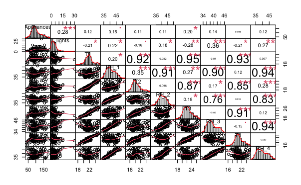

The only variable with a few outliers is lights as shown in figure 1. This may reflect a time where lights were left on while the owners were away, or a malfunction in the internet-of-things (IoT) equipment. The MVA library will be used to check which rows are with extreme outliers and clean them up.

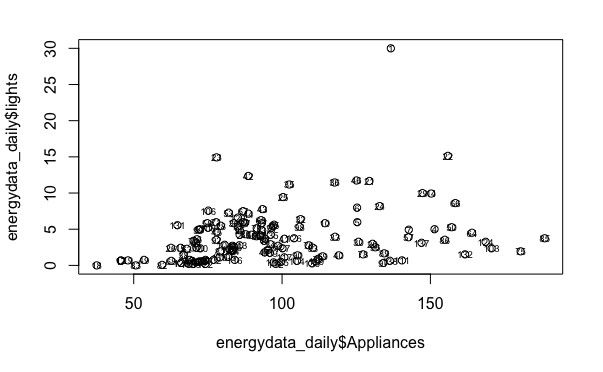

The scatter plot between appliances and lights show days such as 01/11/2016 that appear to be outliers as shown in figure 2. Bvbox will be used to confirm these as outliers.

These are the resulting histograms and correlations of the aggregated energy data after cleaning.

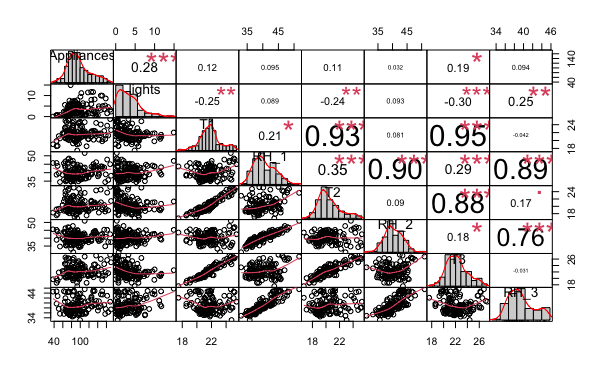

### Correlation Results

There is a positive correlation between appliances and lights energy consumption. Lights energy consumption usually increases when there is occupant in the house/office, the positive correlation with appliances indicates that more appliances are used when the house is occupied.

Higher positive correlation numbers between temperature and humidity reading at different part of the house is expected since the overall inside house environment at different part of the house are related.

## Principle Component Analysis

Principal component analysis is used to reduce the many variables in the energy data and get a few variables that explain most of the variation in the data.

```
Importance of components:
                       Comp.1 Comp.2 Comp.3 Comp.4 Comp.5 Comp.6 Comp.7 Comp.8 Comp.9 Comp.10
Standard deviation       3.26   2.82  1.206  1.089   1.03  0.926  0.827  0.772  0.674   0.579
Proportion of Variance   0.41   0.31  0.056  0.046   0.04  0.033  0.026  0.023  0.017   0.013
Cumulative Proportion    0.41   0.72  0.771  0.817   0.86  0.890  0.917  0.940  0.957   0.970
                       Comp.11 Comp.12 Comp.13 Comp.14 Comp.15 Comp.16 Comp.17 Comp.18
Standard deviation      0.4918  0.3349  0.2915  0.2655  0.2440  0.2385  0.1985  0.1872
Proportion of Variance  0.0093  0.0043  0.0033  0.0027  0.0023  0.0022  0.0015  0.0013
Cumulative Proportion   0.9792  0.9835  0.9868  0.9895  0.9918  0.9939  0.9955  0.9968
                       Comp.19 Comp.20 Comp.21 Comp.22 Comp.23 Comp.24 Comp.25 Comp.26
Standard deviation       0.163 0.12823 0.12708   1e-01 0.08741 0.05965 4.2e-02 2.5e-02
Proportion of Variance   0.001 0.00063 0.00062   4e-04 0.00029 0.00014 6.9e-05 2.4e-05
Cumulative Proportion    0.998 0.99846 0.99908   1e+00 0.99977 0.99991 1.0e+00 1.0e+00
            Comp.1  Comp.2
Appliances   0.019  0.0319
lights      -0.108  0.0935
T1           0.291 -0.0325
RH_1         0.107  0.3185
T2           0.282  0.0305
RH_2         0.068  0.2886
T3           0.296 -0.0210
RH_3         0.013  0.3419
T4           0.283 -0.0718
RH_4         0.063  0.3398
T5           0.291 -0.0358
RH_5        -0.035  0.2549
T6           0.282  0.0394
RH_6        -0.228  0.2079
T7           0.278 -0.1029
RH_7         0.098  0.3182
T8           0.255 -0.1210
RH_8         0.047  0.3359
T9           0.291 -0.0782
RH_9         0.076  0.3262
T_out        0.280  0.0503
Press_mm_hg -0.063 -0.1011
RH_out      -0.148  0.2096
Windspeed   -0.034  0.1425
Visibility  -0.085  0.0061
Tdewpoint    0.248  0.1602
```

## Confirmatory Factor Analysis

In confirmatory factor analysis (CFA), we want to test whether factors correlate to specific manifest variables. Our model tests whether that is the case with the temperature and humidity variables. Remember in our case that we have several instances of both in different locations.

[output not shown]

This can be inspected more closely in the summary. Additionally, we can add some fit indices to test whether the covariance matrix produced by our model fits the non-retricted covariance matrix of the data.

For the data to support our model, we need a root-mean-square-error (SRMR) of less than 0.05, and both goodness-of-fits to be greater than 0.95. The fits are printed below and we conclude that our data doesn’t support our CFA model.

```
[1] "RMSE: 0.115697075478007"
[1] "Goodness-of-Fit: 0.490514948020036"
[1] "Adjusted-Goodness-of-Fit: 0.327281873113834"
[1] "Data does not support the designed CFA model. MODEL IS NOT CONFIRMED!"
```

## Conclusion

The graphical dimensional reduction analysis did show that temperatures from room to room differed in their relationship to appliance energy use. Future analysis should consider aggregating the temperature variables even further, perhaps by section of the house or proximity to specific appliances, so these differences can be examined further.

Both the principal component and cluster analyses demonstrated how useful these tools can be in grouping variables because in our case, we knew which variables should exhibit clusters in the first place. PCA demonstrated this by finding principal components of temperature and humidity as PC1 and PC2 respectively. These were highlighted by K-means clustering when we colored the results separately based on temperature and humidity vectors in the data.

Finally, our confirmatory factor analysis model did not prove to be supported by our original covariance matrix. This may be due to how close the individual temperature and humidity variables were to each other already, which may create some tight tolerances that aren’t useful for CFA. Again, an interesting approach may be to try a model where sections of the house are used as the factors corresponding to the climate readings in specific rooms.

Ultimately, this was an extremely useful data set for understanding both the strengths and limitations of multivariate analysis. While we may not have been able to find many new relationships, it was informative to see how pre-existing clusters revealed themselves as we learned new tools and techniques. In addition, while there were several rich data points collected from this house, the house itself only represents an n of 1 for any population of households we would want to examine to make conclusive statements about energy use and in-house climate more generally. With a larger sample of homes, the findings of multivariate methods applied here could reveal far more interesting relationships.

## Appendix

### Tables

#### Principal Component Analysis

```
Importance of components:
                       Comp.1 Comp.2 Comp.3 Comp.4 Comp.5 Comp.6 Comp.7 Comp.8 Comp.9 Comp.10
Standard deviation       3.26   2.82  1.206  1.089   1.03  0.926  0.827  0.772  0.674   0.579
Proportion of Variance   0.41   0.31  0.056  0.046   0.04  0.033  0.026  0.023  0.017   0.013
Cumulative Proportion    0.41   0.72  0.771  0.817   0.86  0.890  0.917  0.940  0.957   0.970
                       Comp.11 Comp.12 Comp.13 Comp.14 Comp.15 Comp.16 Comp.17 Comp.18
Standard deviation      0.4918  0.3349  0.2915  0.2655  0.2440  0.2385  0.1985  0.1872
Proportion of Variance  0.0093  0.0043  0.0033  0.0027  0.0023  0.0022  0.0015  0.0013
Cumulative Proportion   0.9792  0.9835  0.9868  0.9895  0.9918  0.9939  0.9955  0.9968
                       Comp.19 Comp.20 Comp.21 Comp.22 Comp.23 Comp.24 Comp.25 Comp.26
Standard deviation       0.163 0.12823 0.12708   1e-01 0.08741 0.05965 4.2e-02 2.5e-02
Proportion of Variance   0.001 0.00063 0.00062   4e-04 0.00029 0.00014 6.9e-05 2.4e-05
Cumulative Proportion    0.998 0.99846 0.99908   1e+00 0.99977 0.99991 1.0e+00 1.0e+00
            Comp.1  Comp.2
Appliances   0.019  0.0319
lights      -0.108  0.0935
T1           0.291 -0.0325
RH_1         0.107  0.3185
T2           0.282  0.0305
RH_2         0.068  0.2886
T3           0.296 -0.0210
RH_3         0.013  0.3419
T4           0.283 -0.0718
RH_4         0.063  0.3398
T5           0.291 -0.0358
RH_5        -0.035  0.2549
T6           0.282  0.0394
RH_6        -0.228  0.2079
T7           0.278 -0.1029
RH_7         0.098  0.3182
T8           0.255 -0.1210
RH_8         0.047  0.3359
T9           0.291 -0.0782
RH_9         0.076  0.3262
T_out        0.280  0.0503
Press_mm_hg -0.063 -0.1011
RH_out      -0.148  0.2096
Windspeed   -0.034  0.1425
Visibility  -0.085  0.0061
Tdewpoint    0.248  0.1602
```